# neuron_projekt

```python
#importy
import numpy as np
from matplotlib import pyplot as plt
import pandas as pd
import seaborn as sns
```

```python
#načítavam môj dataset
column_names = ['Country','Created_Date','Estimated_Yearly_Earning','Subscribe_Rank','Subscribers','Type','Uploads','Username','Views','Views_Rank']
df = pd.read_csv('youtuber_top5000.csv',names=column_names,header = 0)
```

```python
#očistím stĺpec Estimated Yearly Earning od \n a Subscribers,Uploads a Views od ,
df['Subscribers'] = df['Subscribers'].str.replace(r',','')
df['Views'] = df['Views'].str.replace(r',','')
df['Uploads'] = df['Uploads'].str.replace(r',','')
df['Estimated_Yearly_Earning'] = df['Estimated_Yearly_Earning'].str.replace(r'\n','')
#Predátujem Subscribers, Uploads a Views na číslo
df['Subscribers'] = pd.to_numeric(df['Subscribers'])
df['Uploads'] = pd.to_numeric(df['Uploads'])
df['Views'] = pd.to_numeric(df['Views'])
```

```python
# zoradím podľa odoberateľov zostupne
df = df.sort_values(by=['Subscribers'],ascending = False)
```

```python
# Očistím od kanálov, ktoré patria k platforme YouTube
df = df[df['Views'] != 0]
```

```python
# Odstránim NaN a vypíšem prvých 5 riadkov
df = df.dropna()
df.head()
```

|  | Country | Created_Date | Estimated_Yearly_Earning | Subscribe_Rank | Subscribers | Type | Uploads | Username | Views | Views_Rank |
| --- | --- | --- | --- | --- | --- | --- | --- | --- | --- | --- |
| 3839 | US | Apr 29th, 2010 | $1.1M - $17.4M | 2 | 84498150 | Comedy | 3743 | PewDiePie | 20351032889 | 9th |
| 3838 | IN | Mar 13th, 2006 | $8.6M - $137.9M | 3 | 84397478 | Music | 13103 | T-Series | 61207135845 | 1st |
| 3834 | US | Nov 15th, 2016 | $1.7M - $26.4M | 7 | 48792429 | Howto | 2691 | 5-Minute Crafts | 12091941670 | 40th |
| 3833 | BR | Mar 21st, 2012 | $1.9M - $30.1M | 8 | 46432034 | Music | 965 | Canal KondZilla | 22910836814 | 6th |
| 3832 | CA | Jan 15th, 2007 | $5.2K - $82.5K | 9 | 43228731 | Entertainment | 132 | Justin Bieber | 601942698 | 3,927th |

### Ako vidíme PewDiePie (kanál patrí do kategórie Comedy) je na prvom mieste a hneď za nim je T-Series (kanál patrí do kategórie Music)

```python
#Popis numerických hodnôt datasetu
df.describe()
```

|  | Subscribe_Rank | Subscribers | Uploads | Views |
| --- | --- | --- | --- | --- |
| count | 3358.000000 | 3.358000e+03 | 3358.000000 | 3.358000e+03 |
| mean | 2487.487493 | 4.469096e+06 | 2275.703693 | 1.334436e+09 |
| std | 1446.317287 | 4.652836e+06 | 9860.856830 | 2.430945e+09 |
| min | 2.000000 | 5.960000e+02 | 1.000000 | 3.652500e+04 |
| 25% | 1231.250000 | 2.268850e+06 | 150.250000 | 2.962005e+08 |
| 50% | 2491.500000 | 2.979924e+06 | 382.000000 | 6.450585e+08 |
| 75% | 3741.250000 | 4.664868e+06 | 1154.750000 | 1.428255e+09 |
| max | 5000.000000 | 8.449815e+07 | 203105.000000 | 6.120714e+10 |

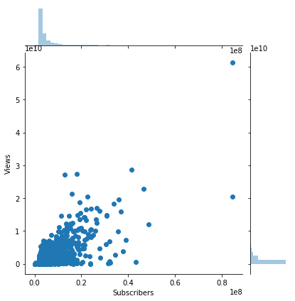

```python
#Vzájomný vzťah medzi Subscribers a Views
sns.jointplot(df['Subscribers'],df['Views'],data=df,kind='scatter')
```

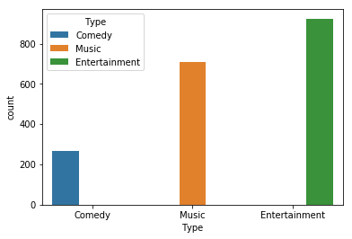

```python
#Počet kanálov v kategórií Comedy, Music a Entertainment
kategorie = ["Comedy","Music",'Entertainment']
new_df = df[df['Type'].isin(kategorie)]
sns.countplot(new_df['Type'],data=new_df,hue="Type")
```

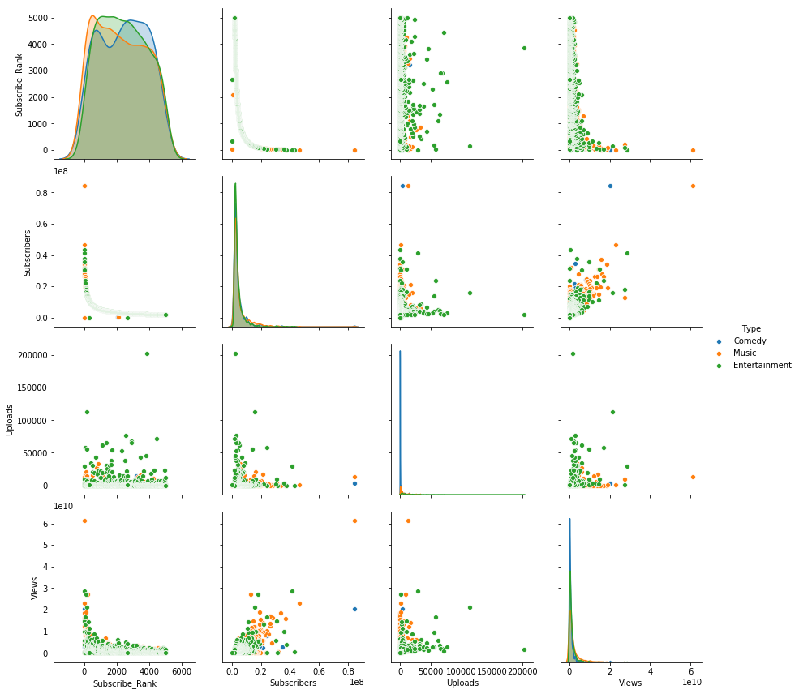

```python
#Ďaľsia vizualizácia množiny údajov na zachytenie vzťahov medzi atribútmi a príslušnými triedami.
sns.pairplot(new_df, hue="Type", height=3, diag_kind="kde")
```

# 1 Formulovanie Problému

### Cieľom práce je spracovať a transformovať dataset YouTube kanálov, aby sa vytvoril model predikcie. Tento model musí predpovedať, v ktorom z troch špecifických typov kanálov bude každý kanál pravdepodobne patriť čo najvyššou presnosťou.

# 2 Popis datasetu

### Dataset obsahuje údaje, ako počet odoberateľov, počet zobrazení videa, počet uploadnutých videí atď. o 5000 najpopulárnejších YouTube kanálov

[figure not shown]

# 3 Predspracovanie

### Pred ponorením do predspracovania musíme rozdeliť naše údaje na tréningové (80%) a na testovacie dáta (20%). Použijem tréningové údaje (budú obsahovať triedy pre typy kanálov), na naučenie modelu, a testovacie údaje (obsahujú iba vlastnosti bez tried) na meranie presnosti nášho predikčného modelu.

```python
from sklearn.model_selection import train_test_split

data = new_df
X = data[['Subscribers', 'Uploads', 'Views']]
y = data['Type']
X_train, X_test, y_train, y_test = train_test_split(X, y, test_size = 0.2)
```

### Kategorické premenné zakódujeme pomocou LabelEncoder(), pretože predikčný model nemôže pracovať s kategorickými premennými.

```python
# Odignorovanie upozornení
pd.options.mode.chained_assignment = None

from sklearn.preprocessing import LabelEncoder
labelencoder = LabelEncoder()
data["Type"] = labelencoder.fit_transform(data["Type"])
type = pd.DataFrame({'Type': ['Comedy', 'Music', 'Entertainment']})
```

### Namiesto 0,1,2 by som chcel mať trojrozmerný vektor. Comedy by teda bola [1,0,0], Entertainment by bola [0,1,0] a Music [0,0,1].

```python
#Pridám na koniec datasetu 3 nové numerické stĺpce, ktoré spolou tvoria trojrozmerný vektor

def create_dummies(df,column_name):
    dummies = pd.get_dummies(df[column_name],prefix=column_name)
    df = pd.concat([df,dummies],axis=1)
    return df


data = create_dummies(data,"Type")
```

```python
data.head()
```

|  | Country | Created_Date | Estimated_Yearly_Earning | Subscribe_Rank | Subscribers | Type | Uploads | Username | Views | Views_Rank | Type_0 | Type_1 | Type_2 |
| --- | --- | --- | --- | --- | --- | --- | --- | --- | --- | --- | --- | --- | --- |
| 3839 | US | Apr 29th, 2010 | $1.1M - $17.4M | 2 | 84498150 | 0 | 3743 | PewDiePie | 20351032889 | 9th | 1 | 0 | 0 |
| 3838 | IN | Mar 13th, 2006 | $8.6M - $137.9M | 3 | 84397478 | 2 | 13103 | T-Series | 61207135845 | 1st | 0 | 0 | 1 |
| 3833 | BR | Mar 21st, 2012 | $1.9M - $30.1M | 8 | 46432034 | 2 | 965 | Canal KondZilla | 22910836814 | 6th | 0 | 0 | 1 |
| 3832 | CA | Jan 15th, 2007 | $5.2K - $82.5K | 9 | 43228731 | 1 | 132 | Justin Bieber | 601942698 | 3,927th | 0 | 1 | 0 |
| 3831 | IN | Sep 20th, 2006 | $4.5M - $71.3M | 10 | 41390812 | 1 | 28784 | SET India | 28660019413 | 3rd | 0 | 1 | 0 |

### Druhou technikou predspracovania je škálovanie mojich údajov pomocou programu StandardScaler(), najmä preto, že MLP je citlivý na nenormalizované funkcie. To mi pomáha urýchliť algoritmus (gradientový zostup) a mať presnejší klasifikátor.

```python
# Aby nevypísal warningy
import warnings
from sklearn.exceptions import DataConversionWarning
warnings.filterwarnings(action='ignore', category=DataConversionWarning)

# Vlastnosti pred strednou normalizáciou
vlastnosti_pred = X_train

# Stredná normalizácia pre rýchlejší classifier
from sklearn.preprocessing import StandardScaler
sc = StandardScaler()



#Transformácia dát
X_train_array = sc.fit_transform(X_train.values)

# Priradím škálované údaje do DataFrame a použijem argumenty indexu a stĺpcov, aby som zachoval svoje pôvodné indexy a názvy stĺpcov:
X_train = pd.DataFrame(X_train_array, index=X_train.index, columns=X_train.columns)

# Vycentrované testovacie dáta na trénovacích dátach
X_test_array = sc.transform(X_test.values)
X_test = pd.DataFrame(X_test_array, index=X_test.index, columns=X_test.columns)
```

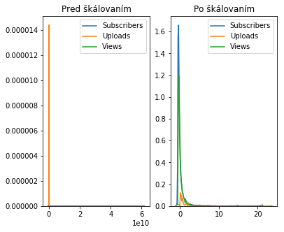

```python
# Pred a po strednej normalizácií
fig, (ax1, ax2) = plt.subplots(ncols=2, figsize=(6, 5))

ax1.set_title('Pred škálovaním')
sns.kdeplot(vlastnosti_pred['Subscribers'], ax=ax1)
sns.kdeplot(vlastnosti_pred['Uploads'], ax=ax1)
sns.kdeplot(vlastnosti_pred['Views'], ax=ax1)


ax2.set_title('Po škálovaním')
sns.kdeplot(X_train['Subscribers'], ax=ax2)
sns.kdeplot(X_train['Uploads'], ax=ax2)
sns.kdeplot(X_train['Views'], ax=ax2)


plt.show()
#Hodnoty sú vlastností už sú teraz rozdelené podľa normálneho rozdelenia
```

# 4 Model & Algoritmus

### Použijem MultiLayer Perceptron (MLP) - klasifikátor s lineárnym dozorom

### Klasifikátor - úloha učenia - koreluje funkcie údajov s vlastnosťami triedy s objektmi skupiny údajov. Odlišuje sa od klastrovania.

### Perceptron - učiaci algoritmus - najzákladnejšia forma neurónovej siete: jednoduchý lineárny klasifikátor.

### Feedforward = výstup akejkoľvek vrstvy neovplyvní tú istú vrstvu.

### Perceptron je binárny v tom zmysle, že neurón je aktivovaný funkciou, ktorá vracia booleovské hodnoty (to zodpovedá modelu s dvoma triedami). Váhy sa aktualizujú na základe týchto booleovských hodnôt, takže na korekciu váhy možno použiť len vstup.

[figure not shown]

### Posilnenie: Perceptronový algoritmus je príkladom posilňovacieho učenia. Po každej prezentácii vstupno-výstupného príkladu vieme len to, či sieť produkuje očakávaný výstup alebo nie. Alternatívou by bolo učenie sa s opravou chýb, aktualizácie váh nie sú ovplyvnené len vstupom, ale aj veľkosťou chyby.

[figure not shown]

### Obrázok 3 - Typy učenia prostredníctvom: „Turingovho spojenectva: skúmanie architektúr neurónovej siete“.

### Multilayer (Viacvrstvový prístup modelovania) - sieť pozostáva z viac ako jednej vrstvy výstupných uzlov, to znamená, že existuje aspoň jedna skrytá vrstva, ktorá odovzdáva vstupy do výstupnej vrstvy.

### Alternatíva k MLP: pravdepodobnostná neurónová sieť založená na bayesovskom prístupe. Podporuje inferenciu okrem odhadu parametrov.

[figure not shown]

### Obrázok 4 - MultiLayer Perceptron (MLP) s jednou skrytou vrstvou. Každý neurón v skrytej vrstve transformuje hodnoty z predchádzajúcej vrstvy váženým lineárnym súčtom, po ktorom nasleduje nelineárna aktivačná funkcia. Výstupná vrstva prijíma hodnoty z poslednej skrytej vrstvy a transformuje ich na výstupné hodnoty.

# 4 MLP pre predikciu kategórií

```python
# import modelu MLP
from sklearn.neural_network import MLPClassifier
# Inicializovanie perceptrónu
mlp = MLPClassifier(hidden_layer_sizes =(100,),solver='adam',learning_rate_init= 0.01, max_iter=500)
```

### learning_rate_init = 0.01: Tento parameter riadi veľkosť kroku pri aktualizácii váh a tu je konštantný. Jeho hodnota by nemala byť príliš veľká (nie konvergujúca) ani príliš malá (príliš pomalá).

### max_iter = 500: maximálny počet epoch (koľkokrát bude každý dátový bod použitý až do konvergencie riešiteľa).

# 5 Trénovanie modelu

### Training = Minimalizácia nákladovej funkcie

### Gradient Descents = Nájdenie hodnoty váh, ktoré minimalizujú nákladovú funkciu.

```python
# Natrénovať model
mlp.fit(X_train, y_train)

# Výstupy
MLPClassifier (activation='relu', alpha=0.0001, batch_size='auto', beta_1=0.9,
beta_2=0.999, early_stopping=False, epsilon=1e-08,
hidden_layer_sizes=10, learning_rate='constant',
learning_rate_init=0.01, max_iter=500, momentum=0.9,
nesterovs_momentum=True, power_t=0.5, random_state=None,
shuffle=True, solver='sgd', tol=0.0001, validation_fraction=0.1,
verbose=False, warm_start=False)
```

[output not shown]

[figure not shown]

### Obrázok 5 - Hyperparametre MLP

### Klasifikátor viacerých tried: Klasifikujte inštancie do jednej z troch alebo viacerých tried.

### Multinomiálne kategorické: Distribúcia cieľových údajov

### Relu: Jednotky v skrytej vrstve aplikujú aktivačnú funkciu na vyvolanie pocitu nelinearity v sieti. Relu nám hovorí, ako blízke sú tieto k 1 (1 = objavíme vzor, konkrétne kombináciu prvkov, ktorá vedie k tomuto výstupu). Bez aktivačnej funkcie by NN bola len lineárna regresná funkcia.

### Kategorická krížová entropia: Stratová funkcia (ako dobré sú parametre).

### Regularizácia L2: Regularizácia pomáha zabrániť nadmernému vybaveniu, tj dobre zovšeobecniť údaje, penalizovaním váh. L2 je súčet váh.

### Veľkosť skupiny = počet tréningových príkladov. Čím vyššia je veľkosť skupiny, tým viac pamäte budete potrebovať.

# 6 Testovanie modelu

```python
# Do Score dáme matrix vlastností (X_test) a požadované hodnoty výstupu y_test
# Predikcie pre X_test sú porovnané s y_test
print(mlp.score(X_test,y_test))
```

```
0.6351706036745407
```

### Pri solver = sgd - Dosiahli sme iba presnosť 58% ~ 60%

### Pri solver = adam sme dosiahli presnosť 62% ~ 68%

### Pri solver = lbfgs sme dosiahlu presnosť 62% ~ 65%

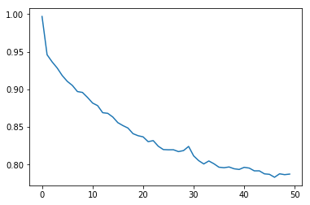

```python
# Zobrazíme graf chýb

errors = mlp.loss_curve_

plt.plot(errors)
plt.show()
```